# Baseflow Data Processing Report (1945-2012)

Temporal Aggregation and Spatial Resolution Analysis

2026-02-11

## 1. Temporal Drift: Is the Region Getting Wetter?

First, we analyze if the maximum baseflow intensity has increased over the 68-year period. This is a classic indicator of climate change impacts on groundwater and soil saturation.

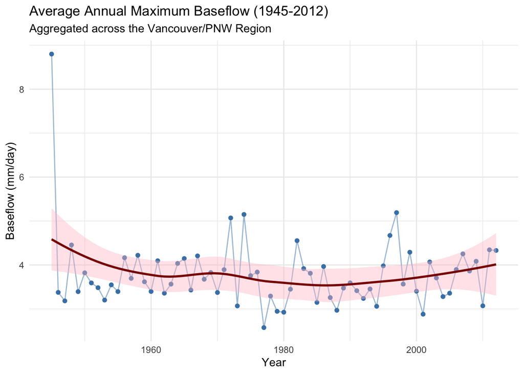

```r
# 3. Plot with a trend line (Loess smoothing)
ggplot(df_trend, aes(x = Year, y = Max_Baseflow)) +
  geom_line(color = "steelblue", alpha = 0.5) +
  geom_point(color = "steelblue") +
  geom_smooth(method = "loess", color = "darkred", fill = "pink") +
  theme_minimal() +
  labs(title = "Average Annual Maximum Baseflow (1945-2012)",
       subtitle = "Aggregated across the Vancouver/PNW Region",
       y = "Baseflow (mm/day)",
       x = "Year")
```

```r
#show the plot
```

## 2.Spatial Visualization (Snapshots)

Let’s visualize the hydrology data for specific dates to ensure the spatial patterns look correct.

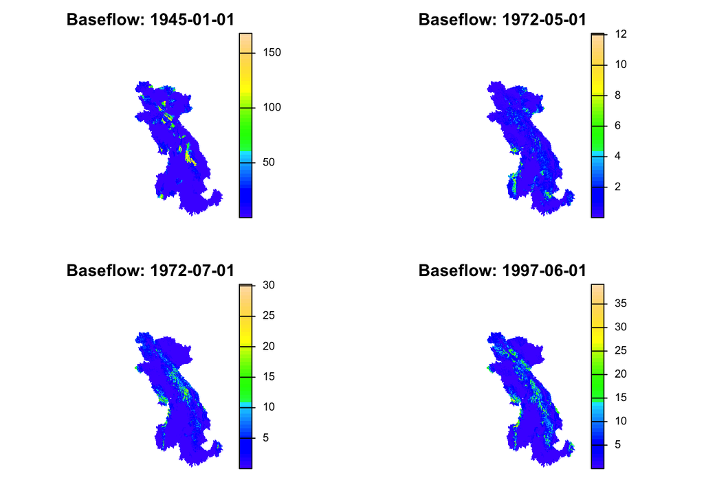

```r
# Define dates to plot
target_dates <- as.Date(c("1945-01-01", "1972-05-01", "1972-07-01", "1997-06-01"))
actual_times <- time(bf_stack)

# Find indices matching these dates
indices <- which(as.Date(actual_times) %in% target_dates)

if (length(indices) > 0) {
  par(mfrow = c(2, 2)) # 2x2 Grid
  for (i in indices) {
    plot(bf_stack[[i]],
         main = paste("Baseflow:", actual_times[i]),
         col = topo.colors(50),
         axes = FALSE)
  }
  par(mfrow = c(1, 1)) # Reset
} else {
  print("Selected dates not found in the dataset.")
}
```

## 3. Interactive Maps for Key Dates

```r
library(terra)
library(leaflet)
n_wettest <- 2  # Number of wettest days to show
target_date <- "1945-07-15"  # Specific date to plot

# ============================================
# Helper Function
# ============================================
create_baseflow_map <- function(layer, title_text) {
  all_values <- terra::values(layer)
  actual_range <- range(all_values, na.rm = TRUE)
  domain_vals <- c(0, actual_range[2])

  pal <- leaflet::colorNumeric(c("#FFFFCC", "#41B6C4", "#0C2C84"),
                                domain = domain_vals,
                                na.color = "transparent")

  leaflet::leaflet() %>%
    leaflet::addProviderTiles(leaflet::providers$CartoDB.Positron) %>%
    leaflet::addRasterImage(layer,
                            colors = pal,
                            opacity = 0.8,
                            project = FALSE,
                            maxBytes = 20 * 1024 * 1024) %>%
    leaflet::addLegend(pal = pal,
                       values = all_values,
                       title = title_text)
}

# ============================================
# 1. Top N Wettest Days
# ============================================
# daily_means <- global(bf_stack, "mean", na.rm = TRUE)
# top_indices <- order(daily_means$mean, decreasing = TRUE)[1:n_wettest]
# top_dates <- time(bf_stack)[top_indices]
#
# top_maps <- lapply(1:n_wettest, function(i) {
#   layer <- bf_stack[[top_indices[i]]]
#   map_title <- sprintf("Rank %d - %s", i, top_dates[i])
#   create_baseflow_map(layer, map_title)
# })
#
# # Display all top maps
# htmltools::tagList(top_maps)

# ============================================
# 2. Specific Date Map
# ============================================
specific_date <- as.Date(target_date)
date_index <- which(time(bf_stack) == specific_date)

if(length(date_index) > 0) {
  cat("\n=== Specific Date Map ===\n")
  cat(sprintf("Date: %s (Day %d)\n", specific_date, date_index))
  #cat(sprintf("Mean flow: %.2f mm\n", daily_means$mean[date_index]))

  specific_layer <- bf_stack[[date_index]]
  create_baseflow_map(specific_layer, paste("Baseflow on", specific_date))
} else {
  cat("\n⚠ Date", target_date, "not found in dataset\n")
  cat("Available range:", as.character(min(time(bf_stack))),
      "to", as.character(max(time(bf_stack))), "\n")
}
```

```
##
## === Specific Date Map ===
## Date: 1945-07-15 (Day 196)
```

[interactive chart not shown]

## 4.Point Extraction Daily

We extract a time series for a specific coordinate. To ensure we don’t pick an ocean pixel (NA), we programmatically find a valid land pixel.

```r
# first_layer <- bf_stack[[1]]
# valid_points <- as.points(first_layer, values=TRUE, na.rm=TRUE)
#
# # 2. Pick a safe sample point (e.g., the 1000th valid point)
# # Ensure we don't go out of bounds if the map is small
# idx <- min(1000, length(valid_points))
# sample_point <- valid_points[idx]
# coords <- crds(sample_point)
#
# print(paste("Extracting data for Lat:", round(coords[1,2], 2),
#             "Lon:", round(coords[1,1], 2)))

# # 1. Find valid land coordinates (not NA) from the first layer
#using the first layer of the yearly max to find valid land coordinates
first_layer <- yearly_max[[1]]
valid_points <- as.points(first_layer, values=TRUE, na.rm=TRUE)

# 2. Pick a safe sample point (e.g., the 1000th valid point)
# Ensure we don't go out of bounds if the map is small
idx <- min(1000, length(valid_points))
sample_point <- valid_points[idx]
coords <- crds(sample_point)

print(paste("Extracting data for Lat:", round(coords[1,2], 2),
            "Lon:", round(coords[1,1], 2)))
```

```
## [1] "Extracting data for Lat: 57.09 Lon: -119.66"
```

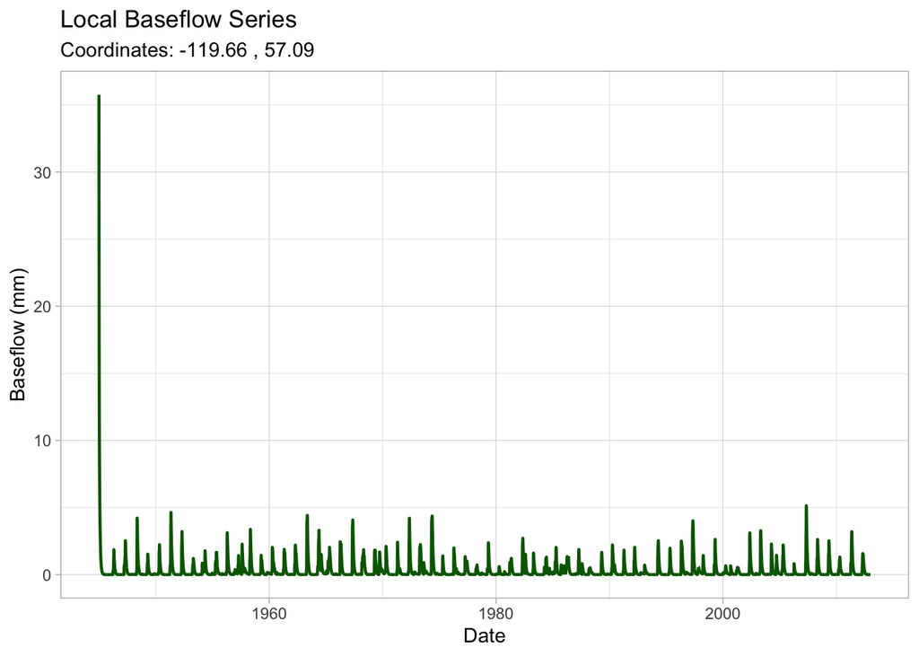

```r
# 3. Extract time series for this location
point_vals <- terra::extract(bf_stack, sample_point, ID=FALSE) # returns a vector

# 4. Create dataframe
point_ts <- data.frame(
  Date = time(bf_stack),
  Baseflow = as.numeric(point_vals)
)

# 5. Plot
ggplot(point_ts, aes(x = Date, y = Baseflow)) +
  geom_line(color = "darkgreen", linewidth = 0.8) +
  theme_light() +
  labs(title = paste("Local Baseflow Series"),
       subtitle = paste("Coordinates:", round(coords[1,1], 2), ",", round(coords[1,2], 2)),
       y = "Baseflow (mm)")
```

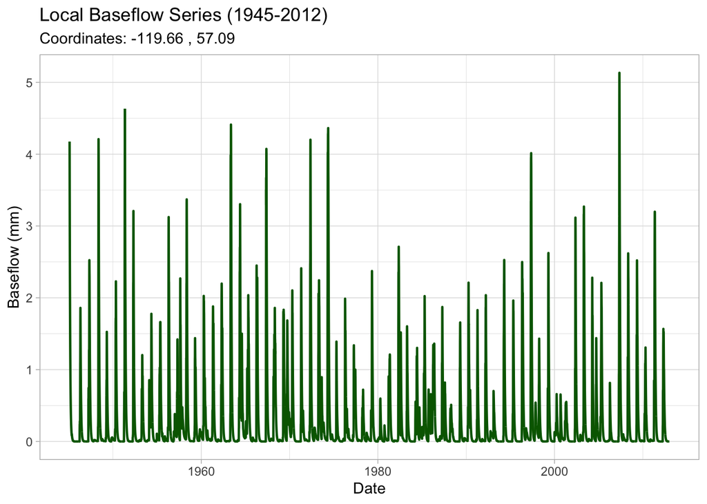

```r
#make the data start from 1945, so filter the data frame and plot again
point_ts <- point_ts %>% filter(Date >= as.Date("1945-02-02") & Date <= as.Date("2012-12-31"))
ggplot(point_ts, aes(x = Date, y = Baseflow)) +
  geom_line(color = "darkgreen", linewidth = 0.8) +
  theme_light() +
  labs(title = paste("Local Baseflow Series (1945-2012)"),
       subtitle = paste("Coordinates:", round(coords[1,1], 2), ",", round(coords[1,2], 2)),
       y = "Baseflow (mm)")
```

```r
#make the plot wider and there are a lot x value (days)
library(plotly)
p <- ggplot(point_ts, aes(x = Date, y = Baseflow)) +
  geom_line(color = "darkgreen") +
  theme_light()

ggplotly(p) # This makes the plot interactive in your RStudio Viewer
```

[interactive chart not shown]